# Backgroud

### TMDb movie data

#### This data set contains information about 10,000 movies collected from The Movie Database (TMDb), including user ratings and revenue.

- Certain columns, like ‘cast’ and ‘genres’, contain multiple values separated by pipe (|) characters.
- There are some odd characters in the ‘cast’ column. Don’t worry about cleaning them. You can leave them as is.
- The final two columns ending with “_adj” show the budget and revenue of the associated movie in terms of 2010 dollars, accounting for inflation over time.

### Data explore work flow:

1. Set up data frame:Moving all data which I need in the data frame.
2. Clean data set:Clean all the data set,as below performance:
3. Each row describes a single object
4. Each column describes a property of that object
5. Columns are numeric whenever appropriate
6. Columns contain atomic properties that cannot be further decomposed
7. Explore all the data graph.
8. Explore data group to compare with data frame.

## 1. Loading data from CSVs

### 1.1 System setting

```python
import warnings
warnings.filterwarnings('ignore')
```

```python
%matplotlib inline

import matplotlib.pyplot as plt
import pandas as pd
import numpy as np

pd.set_option('display.width',500)
pd.set_option('display.max_columns',100)

def remove_border(axes=None, top=False, right=False, left=True, bottom=True):

    ax = axes or plt.gca()
    ax.spines['top'].set_visible(top)
    ax.spines['right'].set_visible(right)
    ax.spines['left'].set_visible(left)
    ax.spines['bottom'].set_visible(bottom)

    ax.yaxis.set_ticks_position('none')
    ax.xaxis.set_ticks_position('none')

    if top:
        ax.xaxis.tick_top()
    if bottom:
        ax.xaxis.tick_bottom()
    if left:
        ax.yaxis.tick_left()
    if right:
        ax.yaxis.tick_right()
```

### 1.2 Import Data

```python
data = pd.read_csv('tmdb-movies.csv')

data.head()
```

|  | id | imdb_id | popularity | budget | revenue | original_title | cast | homepage | director | tagline | keywords | overview | runtime | genres | production_companies | release_date | vote_count | vote_average | release_year | budget_adj | revenue_adj |
| --- | --- | --- | --- | --- | --- | --- | --- | --- | --- | --- | --- | --- | --- | --- | --- | --- | --- | --- | --- | --- | --- |
| 0 | 135397 | tt0369610 | 32.985763 | 150000000 | 1513528810 | Jurassic World | Chris Pratt\|Bryce Dallas Howard\|Irrfan Khan\|Vi... | http://www.jurassicworld.com/ | Colin Trevorrow | The park is open. | monster\|dna\|tyrannosaurus rex\|velociraptor\|island | Twenty-two years after the events of Jurassic ... | 124 | Action\|Adventure\|Science Fiction\|Thriller | Universal Studios\|Amblin Entertainment\|Legenda... | 6/9/15 | 5562 | 6.5 | 2015 | 1.379999e+08 | 1.392446e+09 |
| 1 | 76341 | tt1392190 | 28.419936 | 150000000 | 378436354 | Mad Max: Fury Road | Tom Hardy\|Charlize Theron\|Hugh Keays-Byrne\|Nic... | http://www.madmaxmovie.com/ | George Miller | What a Lovely Day. | future\|chase\|post-apocalyptic\|dystopia\|australia | An apocalyptic story set in the furthest reach... | 120 | Action\|Adventure\|Science Fiction\|Thriller | Village Roadshow Pictures\|Kennedy Miller Produ... | 5/13/15 | 6185 | 7.1 | 2015 | 1.379999e+08 | 3.481613e+08 |
| 2 | 262500 | tt2908446 | 13.112507 | 110000000 | 295238201 | Insurgent | Shailene Woodley\|Theo James\|Kate Winslet\|Ansel... | http://www.thedivergentseries.movie/#insurgent | Robert Schwentke | One Choice Can Destroy You | based on novel\|revolution\|dystopia\|sequel\|dyst... | Beatrice Prior must confront her inner demons ... | 119 | Adventure\|Science Fiction\|Thriller | Summit Entertainment\|Mandeville Films\|Red Wago... | 3/18/15 | 2480 | 6.3 | 2015 | 1.012000e+08 | 2.716190e+08 |
| 3 | 140607 | tt2488496 | 11.173104 | 200000000 | 2068178225 | Star Wars: The Force Awakens | Harrison Ford\|Mark Hamill\|Carrie Fisher\|Adam D... | http://www.starwars.com/films/star-wars-episod... | J.J. Abrams | Every generation has a story. | android\|spaceship\|jedi\|space opera\|3d | Thirty years after defeating the Galactic Empi... | 136 | Action\|Adventure\|Science Fiction\|Fantasy | Lucasfilm\|Truenorth Productions\|Bad Robot | 12/15/15 | 5292 | 7.5 | 2015 | 1.839999e+08 | 1.902723e+09 |
| 4 | 168259 | tt2820852 | 9.335014 | 190000000 | 1506249360 | Furious 7 | Vin Diesel\|Paul Walker\|Jason Statham\|Michelle ... | http://www.furious7.com/ | James Wan | Vengeance Hits Home | car race\|speed\|revenge\|suspense\|car | Deckard Shaw seeks revenge against Dominic Tor... | 137 | Action\|Crime\|Thriller | Universal Pictures\|Original Film\|Media Rights ... | 4/1/15 | 2947 | 7.3 | 2015 | 1.747999e+08 | 1.385749e+09 |

## 2. Interested questions was thinking about

1. What kind of genres as high vote rate?
2. Had the high vote rate movies genre have different in the release years?
3. Is that the high vote rate movies base on the runtime?
4. In different release year,which kind of genres are more produced?

## 3.Fixing Data Types

```python
data.isnull().sum()
```

```
id                         0
imdb_id                   10
popularity                 0
budget                     0
revenue                    0
original_title             0
cast                      76
homepage                7930
director                  44
tagline                 2824
keywords                1493
overview                   4
runtime                    0
genres                    23
production_companies    1030
release_date               0
vote_count                 0
vote_average               0
release_year               0
budget_adj                 0
revenue_adj                0
dtype: int64
```

```python
data.fillna("Unknown",inplace=True)
```

```python
data.isnull().sum()
```

```
id                      0
imdb_id                 0
popularity              0
budget                  0
revenue                 0
original_title          0
cast                    0
homepage                0
director                0
tagline                 0
keywords                0
overview                0
runtime                 0
genres                  0
production_companies    0
release_date            0
vote_count              0
vote_average            0
release_year            0
budget_adj              0
revenue_adj             0
dtype: int64
```

#### 3.2 After fixed the missing data,seperation the genres information for several columns,and every cell shows True or False.

```python
genres = set()

for m in data.genres:
    genres.update(g for g in m.split('|'))
genres = sorted(genres)

for genre in genres:
    data[genre] = [genre in movie.split('|') for movie in data.genres]

data.head()
```

|  | id | imdb_id | popularity | budget | revenue | original_title | cast | homepage | director | tagline | keywords | overview | runtime | genres | production_companies | release_date | vote_count | vote_average | release_year | budget_adj | revenue_adj | Action | Adventure | Animation | Comedy | Crime | Documentary | Drama | Family | … |
| --- | --- | --- | --- | --- | --- | --- | --- | --- | --- | --- | --- | --- | --- | --- | --- | --- | --- | --- | --- | --- | --- | --- | --- | --- | --- | --- | --- | --- | --- | --- |
| 0 | 135397 | tt0369610 | 32.985763 | 150000000 | 1513528810 | Jurassic World | Chris Pratt\|Bryce Dallas Howard\|Irrfan Khan\|Vi... | http://www.jurassicworld.com/ | Colin Trevorrow | The park is open. | monster\|dna\|tyrannosaurus rex\|velociraptor\|island | Twenty-two years after the events of Jurassic ... | 124 | Action\|Adventure\|Science Fiction\|Thriller | Universal Studios\|Amblin Entertainment\|Legenda... | 6/9/15 | 5562 | 6.5 | 2015 | 1.379999e+08 | 1.392446e+09 | True | True | False | False | False | False | False | False | … |
| 1 | 76341 | tt1392190 | 28.419936 | 150000000 | 378436354 | Mad Max: Fury Road | Tom Hardy\|Charlize Theron\|Hugh Keays-Byrne\|Nic... | http://www.madmaxmovie.com/ | George Miller | What a Lovely Day. | future\|chase\|post-apocalyptic\|dystopia\|australia | An apocalyptic story set in the furthest reach... | 120 | Action\|Adventure\|Science Fiction\|Thriller | Village Roadshow Pictures\|Kennedy Miller Produ... | 5/13/15 | 6185 | 7.1 | 2015 | 1.379999e+08 | 3.481613e+08 | True | True | False | False | False | False | False | False | … |
| 2 | 262500 | tt2908446 | 13.112507 | 110000000 | 295238201 | Insurgent | Shailene Woodley\|Theo James\|Kate Winslet\|Ansel... | http://www.thedivergentseries.movie/#insurgent | Robert Schwentke | One Choice Can Destroy You | based on novel\|revolution\|dystopia\|sequel\|dyst... | Beatrice Prior must confront her inner demons ... | 119 | Adventure\|Science Fiction\|Thriller | Summit Entertainment\|Mandeville Films\|Red Wago... | 3/18/15 | 2480 | 6.3 | 2015 | 1.012000e+08 | 2.716190e+08 | False | True | False | False | False | False | False | False | … |
| 3 | 140607 | tt2488496 | 11.173104 | 200000000 | 2068178225 | Star Wars: The Force Awakens | Harrison Ford\|Mark Hamill\|Carrie Fisher\|Adam D... | http://www.starwars.com/films/star-wars-episod... | J.J. Abrams | Every generation has a story. | android\|spaceship\|jedi\|space opera\|3d | Thirty years after defeating the Galactic Empi... | 136 | Action\|Adventure\|Science Fiction\|Fantasy | Lucasfilm\|Truenorth Productions\|Bad Robot | 12/15/15 | 5292 | 7.5 | 2015 | 1.839999e+08 | 1.902723e+09 | True | True | False | False | False | False | False | False | … |
| 4 | 168259 | tt2820852 | 9.335014 | 190000000 | 1506249360 | Furious 7 | Vin Diesel\|Paul Walker\|Jason Statham\|Michelle ... | http://www.furious7.com/ | James Wan | Vengeance Hits Home | car race\|speed\|revenge\|suspense\|car | Deckard Shaw seeks revenge against Dominic Tor... | 137 | Action\|Crime\|Thriller | Universal Pictures\|Original Film\|Media Rights ... | 4/1/15 | 2947 | 7.3 | 2015 | 1.747999e+08 | 1.385749e+09 | True | False | False | False | True | False | False | False | … |

## 4. Investigating the Data

### 4.1 To realize data from .describe

```python
data[['runtime','vote_count','vote_average','release_year']].describe()
```

|  | runtime | vote_count | vote_average | release_year |
| --- | --- | --- | --- | --- |
| count | 10866.000000 | 10866.000000 | 10866.000000 | 10866.000000 |
| mean | 102.070863 | 217.389748 | 5.974922 | 2001.322658 |
| std | 31.381405 | 575.619058 | 0.935142 | 12.812941 |
| min | 0.000000 | 10.000000 | 1.500000 | 1960.000000 |
| 25% | 90.000000 | 17.000000 | 5.400000 | 1995.000000 |
| 50% | 99.000000 | 38.000000 | 6.000000 | 2006.000000 |
| 75% | 111.000000 | 145.750000 | 6.600000 | 2011.000000 |
| max | 900.000000 | 9767.000000 | 9.200000 | 2015.000000 |

### 4.2 Find the length of 0, and mark them to NAN.

```python
print((len(data[data.runtime==0])))

data.runtime[data.runtime == 0] = np.nan
```

```
31
```

```python
data.runtime.describe()
```

```
count    10835.000000
mean       102.362898
std         30.946957
min          2.000000
25%         90.000000
50%         99.000000
75%        112.000000
max        900.000000
Name: runtime, dtype: float64
```

## 5. Exploring movie release_year

### There are many movies release in recent year,and it can be investigate vote_average.

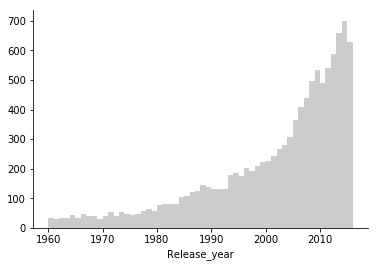

```python
plt.hist(data.release_year,bins=np.arange(1960,2017),color='#cccccc')
plt.xlabel("Release_year")
remove_border()
```

## 5.1 Exploring movie vote average

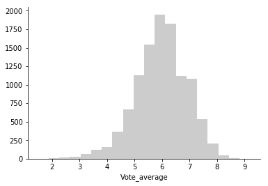

```python
plt.hist(data.vote_average,bins=20,color='#cccccc')
plt.xlabel("Vote_average")
remove_border()
```

## 5.2 Exploring movie Runtime distribution

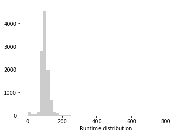

```python
plt.hist(data.runtime.dropna(),bins=50,color='#cccccc')
plt.xlabel("Runtime distribution")
remove_border()
```

## 5.3 Vote_average between Release_year relationship

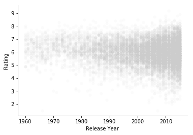

```python
plt.scatter(data.release_year,data.vote_average,lw=0,alpha=.08,color='#cccccc')
plt.xlabel("Release Year")
plt.ylabel("Rating")
remove_border()
```

## 5.4 The number of votes between vote rating

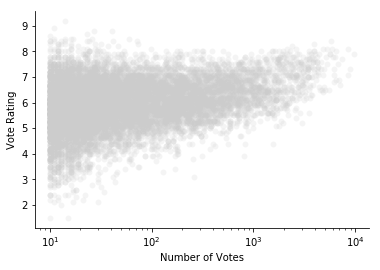

```python
plt.scatter(data.vote_count,data.vote_average,lw=0,alpha=.2,color=('#cccccc'))
plt.xlabel("Number of Votes")
plt.ylabel("Vote Rating")
plt.xscale('log')
remove_border()
```

### 5.5 Invesigate vote score (the lowest and the highest)

```python
data[data.vote_average == data.vote_average.min()][['original_title','release_year','vote_average','genres']]
```

|  | original_title | release_year | vote_average | genres |
| --- | --- | --- | --- | --- |
| 7772 | Transmorphers | 2007 | 1.5 | Action\|Adventure\|Science Fiction |
| 10865 | Manos: The Hands of Fate | 1966 | 1.5 | Horror |

```python
data[data.vote_average == data.vote_average.max()][['original_title','release_year','vote_average','genres']]
```

|  | original_title | release_year | vote_average | genres |
| --- | --- | --- | --- | --- |
| 3894 | The Story of Film: An Odyssey | 2011 | 9.2 | Documentary |

### 5.6 Which genres was the most frequently in Data

```python
genre_c = np.sort(data[genres].sum())[::-1]
pd.DataFrame({'Genre Count':genre_c})
```

|  | Genre Count |
| --- | --- |
| 0 | 4761 |
| 1 | 3793 |
| 2 | 2908 |
| 3 | 2385 |
| 4 | 1712 |
| 5 | 1637 |
| 6 | 1471 |
| 7 | 1355 |
| 8 | 1231 |
| 9 | 1230 |
| 10 | 916 |
| 11 | 810 |
| 12 | 699 |
| 13 | 520 |
| 14 | 408 |
| 15 | 334 |
| 16 | 270 |
| 17 | 188 |
| 18 | 167 |
| 19 | 165 |
| 20 | 23 |

### 5.7 The average of genres in the movies

```python
genre_count = data[genres].sum(axis=1)
print(("Average movie has %0.2f genres" % genre_count.mean()))
genre_count.describe()
```

```
Average movie has 2.48 genres
```

```
count    10866.000000
mean         2.483251
std          1.116560
min          1.000000
25%          2.000000
50%          2.000000
75%          3.000000
max          5.000000
dtype: float64
```

## 6.Explore group feature

```python
decade =  (data.release_year // 10) * 10

tyd = data[['original_title', 'release_year']]
tyd['decade'] = decade

tyd.head()
```

|  | original_title | release_year | decade |
| --- | --- | --- | --- |
| 0 | Jurassic World | 2015 | 2010 |
| 1 | Mad Max: Fury Road | 2015 | 2010 |
| 2 | Insurgent | 2015 | 2010 |
| 3 | Star Wars: The Force Awakens | 2015 | 2010 |
| 4 | Furious 7 | 2015 | 2010 |

```
release_year
1960    6.246133
1970    6.367323
1980    6.079398
1990    5.999263
2000    5.921224
2010    5.902745
Name: Decade Mean, dtype: float64
```

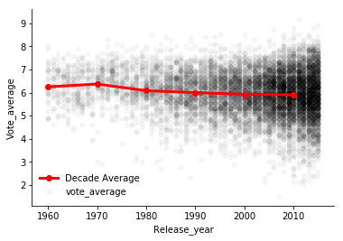

```python
decade_mean = data.groupby(decade).vote_average.mean()
decade_mean.name = 'Decade Mean'
print(decade_mean)
plt.plot(decade_mean.index, decade_mean.values, 'o-',
        color='r', lw=3, label='Decade Average')
plt.scatter(data.release_year, data.vote_average, alpha=.04, lw=0, color='k')
plt.xlabel("Release_year")
plt.ylabel("Vote_average")
plt.legend(frameon=False)
remove_border()
```

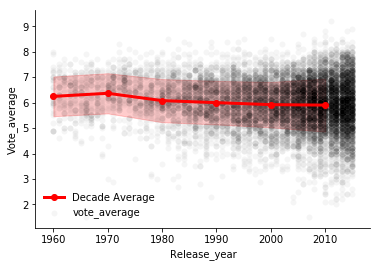

```python
grouped_scores = data.groupby(decade).vote_average

mean = grouped_scores.mean()
std = grouped_scores.std()

plt.plot(decade_mean.index, decade_mean.values, 'o-',
        color='r', lw=3, label='Decade Average')
plt.fill_between(decade_mean.index, (decade_mean + std).values,
                 (decade_mean - std).values, color='r', alpha=.2)
plt.scatter(data.release_year, data.vote_average, alpha=.04, lw=0, color='k')
plt.xlabel("Release_year")
plt.ylabel("Vote_average")
plt.legend(frameon=False)
remove_border()
```

```python
for release_year, subset in data.groupby('release_year'):
    print((release_year, subset[subset.vote_average == subset.vote_average.max()].original_title.values))
```

```
(1960, array(['Psycho'], dtype=object))
(1961, array(['One, Two, Three'], dtype=object))
(1962, array(['To Kill a Mockingbird'], dtype=object))
(1963, array(['Charade', 'The Great Escape'], dtype=object))
(1964, array(['Dr. Strangelove or: How I Learned to Stop Worrying and Love the Bomb'], dtype=object))
(1965, array(['A Charlie Brown Christmas'], dtype=object))
(1966, array(['Winnie the Pooh and the Honey Tree'], dtype=object))
(1967, array(['Bonnie and Clyde'], dtype=object))
(1968, array(['2001: A Space Odyssey'], dtype=object))
(1969, array(['Kes'], dtype=object))
(1970, array(['Gimme Shelter'], dtype=object))
(1971, array(['A Clockwork Orange'], dtype=object))
(1972, array(['The Godfather'], dtype=object))
(1973, array(['The Sting', 'Paper Moon'], dtype=object))
(1974, array(['The Godfather: Part II'], dtype=object))
(1975, array(["One Flew Over the Cuckoo's Nest"], dtype=object))
(1976, array(['Taxi Driver'], dtype=object))
(1977, array(['Star Wars'], dtype=object))
(1978, array(['The Last Waltz'], dtype=object))
(1979, array(['Apocalypse Now'], dtype=object))
(1980, array(['The Empire Strikes Back'], dtype=object))
(1981, array(['Queen - Rock Montreal'], dtype=object))
(1982, array(['Vincent'], dtype=object))
(1983, array(["Michael Jackson's Thriller"], dtype=object))
(1984, array(['Stop Making Sense'], dtype=object))
(1985, array(['Shoah'], dtype=object))
(1986, array(['MacskafogÃ³'], dtype=object))
(1987, array(['Full Metal Jacket'], dtype=object))
(1988, array(['The Thin Blue Line'], dtype=object))
(1989, array(['Depeche Mode: 101'], dtype=object))
(1990, array(['Goodfellas'], dtype=object))
(1991, array(['The Silence of the Lambs'], dtype=object))
(1992, array(['Bill Hicks: Relentless'], dtype=object))
(1993, array(["Schindler's List"], dtype=object))
(1994, array(['The Shawshank Redemption'], dtype=object))
(1995, array(['A Personal Journey with Martin Scorsese Through American Movies'], dtype=object))
(1996, array(['La Belle verte',
       'Paradise Lost: The Child Murders at Robin Hood Hills'], dtype=object))
(1997, array(["Geri's Game"], dtype=object))
(1998, array(['American History X'], dtype=object))
(1999, array(['Fight Club'], dtype=object))
(2000, array(["Dave Chappelle: Killin' Them Softly"], dtype=object))
(2001, array(['Band of Brothers'], dtype=object))
(2002, array(['The Century of the Self'], dtype=object))
(2003, array(['Tupac: Resurrection'], dtype=object))
(2004, array(['Eternal Sunshine of the Spotless Mind'], dtype=object))
(2005, array(['The Devil and Daniel Johnston'], dtype=object))
(2006, array(['Pink Floyd: Pulse'], dtype=object))
(2007, array(['The King of Kong'], dtype=object))
(2008, array(['John Mayer: Where the Light Is Live in Los Angeles'], dtype=object))
(2009, array(['Iron Maiden: Flight 666'], dtype=object))
(2010, array(['Life Cycles'], dtype=object))
(2011, array(['The Story of Film: An Odyssey'], dtype=object))
(2012, array(['London 2012 Olympic Opening Ceremony: Isles of Wonder',
       'One Direction: Up All Night - The Live Tour'], dtype=object))
(2013, array(['Doctor Who: The Time of the Doctor'], dtype=object))
(2014, array(['Black Mirror: White Christmas'], dtype=object))
(2015, array(['The Mask You Live In'], dtype=object))
```

## 7. Small group of genres

#### Let's look at release years,runtime,and vote average distribution in different genres(red backgroud).all the movies data set to gray backgroud.

### 7.1 The popular genres in release years

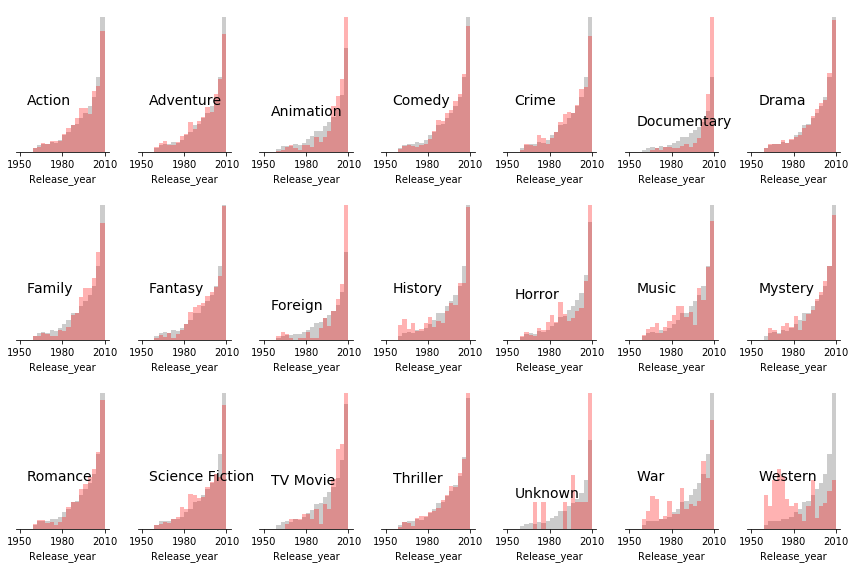

```python
fig, axes = plt.subplots(nrows=3, ncols=7, figsize=(12, 8),
                         tight_layout=True)

bins = np.arange(1950, 2013, 3)
for ax, genre in zip(axes.ravel(), genres):
    ax.hist(data[data[genre] == 1].release_year,
            bins=bins, histtype='stepfilled', normed=True, color='r', alpha=.3, ec='none')
    ax.hist(data.release_year, bins=bins, histtype='stepfilled', ec='None', normed=True, zorder=0, color='#cccccc')

    ax.annotate(genre, xy=(1955, 3e-2), fontsize=14)
    ax.xaxis.set_ticks(np.arange(1950, 2013, 30))
    ax.set_yticks([])
    remove_border(ax, left=False)
    ax.set_xlabel('Release_year')
```

### 7.2 Runtime in different genres

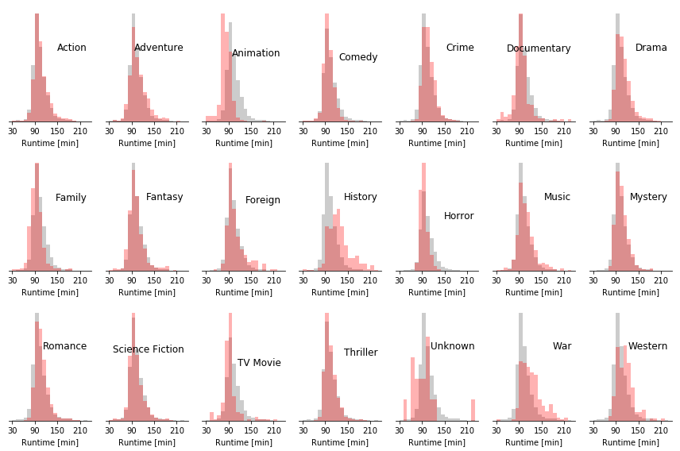

```python
fig, axes = plt.subplots(nrows=3, ncols=7, figsize=(12, 8), tight_layout=True)

bins = np.arange(30, 240, 10)

for ax, genre in zip(axes.ravel(), genres):
    ax.hist(data[data[genre] == 1].runtime.dropna(),
            bins=bins, histtype='stepfilled', color='r', ec='none', alpha=.3, normed=True)

    ax.hist(data.runtime.dropna(), bins=bins, normed=True,
            histtype='stepfilled', ec='none', color='#cccccc',
            zorder=0)

    ax.set_xticks(np.arange(30, 240, 60))
    ax.set_yticks([])
    ax.set_xlabel("Runtime [min]")
    remove_border(ax, left=False)
    ax.annotate(genre, xy=(230, .02), ha='right', fontsize=12)
```

### 7.3 Vote average in different genres

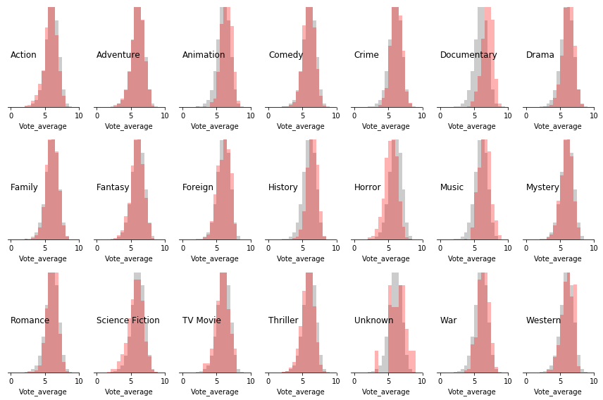

```python
fig, axes = plt.subplots(nrows=3, ncols=7, figsize=(12, 8), tight_layout=True)

bins = np.arange(0, 10, .5)

for ax, genre in zip(axes.ravel(), genres):
    ax.hist(data[data[genre] == 1].vote_average,
            bins=bins, histtype='stepfilled', color='r', ec='none', alpha=.3, normed=True)

    ax.hist(data.vote_average, bins=bins, normed=True,
            histtype='stepfilled', ec='none', color='#cccccc',
            zorder=0)

    ax.set_yticks([])
    ax.set_xlabel("Vote_average")
    remove_border(ax, left=False)
    ax.set_ylim(0, .4)
    ax.annotate(genre, xy=(0, .2), ha='left', fontsize=12)
```

## 8. Conclusion

#### In conclusion, there have enough movie data to support the data analysis result,and we also can see in different release year of vote average be partial to kind of genres.However,the data set didn't definit what kind of person to vote average of movies. In otherwise,that maybe different vote average for people which likes female,male,seniors and kids.

## 9. Reference

- [Data Science](https://www.kesci.com/apps/home/project/59435d2a23168e6e892555e8)
- [Data wrangling with Pandas](http://nbviewer.jupyter.org/urls/gist.github.com/fonnesbeck/5850413/raw/3a9406c73365480bc58d5e75bc80f7962243ba17/2.+Data+Wrangling+with+Pandas.ipynb)